# Quantified Grad Student

2014-06-24

## What I'm going to present

- Intro - why did I do this
- data collection - what kind of data did I gather
- analysis
- conclusions
- future directions - other questions?

## Motivation

- Entering grad school - how much time do I need to invest?
- Anecdotal: it will take all of your time

## One data point

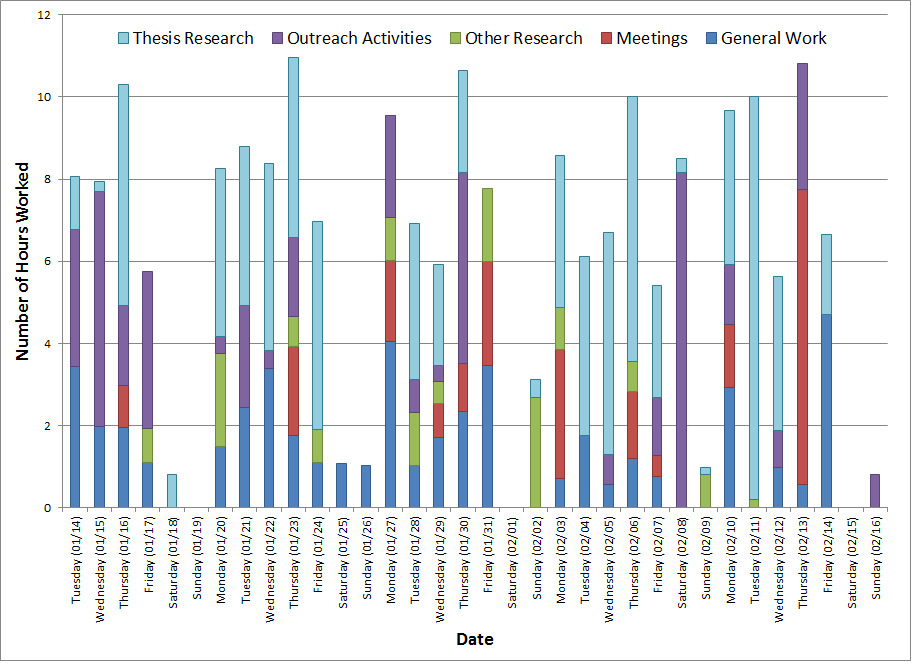

(http://rddenton.blogspot.com/2014/02/who-works-80-hours-week-in-academia.html)

## But, who am I?

Grad student in Plant Biology

- Genomics (computational work), and local adaptation (field / greenhouse / lab work)
- How do I compare to other Grad students?
- I'm probably not very representative… but then what is a "normal" grad student?

## Questions

- How much time do I invest in Grad School?
  - How much time do I spend on campus?
  - How much time am I working on grad school stuff?
  - What percent of time that I am on campus am I actually getting work done?

## Data Collection

## Tools

- Android App: Gleeo
- Google Spreadsheet on my phone

## Data collected

- Time doing work
- Time I'm on campus

## But how do I split my time up?

How many categories?

- Tracked everything in a spreadsheet for a week
- Partition the tasks into categories, with the least amount going into a "misc" bin
- Still iterating, implement another scheme starting fall semester

## Analysis

## campus time

- time that I am at campus each day, Monday - Friday

## How long am I at campus?

[figure not shown]

```
##  Min.  Mean  Max.
##  4.23  9.08 12.70
```

## Grouped by weekday?

[figure not shown]

## Time per week?

[figure not shown]

```
## Min. Mean Max.
## 31.4 42.6 51.6
```

## Productive Time per day

\[ ProductiveTime = Total Tracked Time - Personal Tracked Time \]

## Distribution of Productive Time per day

[figure not shown]

## Distribution of Productive Time per M-F

[figure not shown]

Mon-Fri effect not statistically significant

## How does Productive Time vary by week?

[figure not shown]

## Weekly Productive Time

[figure not shown]

```
## Min. Mean Max.
## 15.8 27.2 35.7
```

## Efficiency

- When I am at campus, how much time of that am I actually working? \[ Efficiency = \frac{Total Tracked Time - Personal Tracked Time}{Time At Campus} \]

## What is the distribution of my efficiency?

[figure not shown]

```
##  Min.  Mean  Max.
## 0.341 0.572 0.855
```

## How does my efficiency vary from M-F?

[figure not shown]

## How does my efficicency vary by week?

[figure not shown]

## In Summary

I spend a mean of **9.08 hrs per day**, and **42.6 hrs per week** at campus

Day:

```
##  Min.  Mean  Max.
##  4.23  9.08 12.70
```

Week:

```
## Min. Mean Max.
## 31.4 42.6 51.6
```

## Project Data

- I haven't used this yet
- next goal: make a graph of time invested in projects as a function of date

## Self Improvement?

- I've answered the questions I started with, but how can I use this to improve my studies?
- Act of tracking improving my focus?
- Guilt of bad data?

Advisor says:

> "…issues of Brownian Motion in accomplishing your projects…"

## Future work

More questions, more data – which are worth my time in pursuing? - Rescuetime seems easy to implement and yield more data on what I am doing when I am working on a computer - How much do I read? - time tracking data gets at this, but how many articles do I read? - I store my notes in markdown files, but this misses the ones that I read for my prelim (I read them, incorporated and cited them, without taking down notes)

- I want to get more "Deep Thought" time in (a la Cal Newport), what kind of metrics can I measure to view this
- what kind of metrics reflect success in Grad School?
- I've measured time in grad schol to get a sense of how much I am investing, but what can I measure to actually improve what I am doing?

## Tracking reading

How many articles does a grad student read? Already my data is kind of poor … see above

## Want more R?

TCRUG - [Twin Cities R User Group](http://www.meetup.com/twincitiesrug/events/189558232/)

- Thursday 6:30 PM, June 26, 2014
- University of Minnesota, Molecular and Cellular Biology Building room MCB 2-122
- 420 Washington Avenue SE , Minneapolis, MN